# Tutorial

Analysis of head eSports MOBA phenomenon: League of Legends

Welcome to Data Science Rift

We will be walking through some of the basics of collecting, cleaning and analyzing data. Python is a language with powerful tools built in, perfect for today's data scientist. If you are new to Python, like my self, do not worry we will be easing into all the concepts and code. Begin by importing these four libraries

```python
import pandas as pd
import numpy as np
import matplotlib.pyplot as plt
from scipy import stats
```

Next we will be using panda to read in data tables for excel csv files. Feel free to download and use your own files, but this tutorial and its will be based one data from https://www.kaggle.com/chuckephron/leagueoflegends#_columns.csv an example of one of the data frames made is below

```python
#gold and bans need tidying
columns = pd.read_csv("_columns.csv")
bans = pd.read_csv("bans.csv")
gold = pd.read_csv("gold.csv")
kills = pd.read_csv("kills.csv")
LoL = pd.read_csv("LeagueofLegends.csv")
matchinfo = pd.read_csv("matchinfo.csv")
monsters = pd.read_csv("monsters.csv")
structures = pd.read_csv("structures.csv")
LoL
```

|  | League | Year | Season | Type | blueTeamTag | bResult | rResult | redTeamTag | gamelength | golddiff | ... | redMiddleChamp | goldredMiddle | redADC | redADCChamp | goldredADC | redSupport | redSupportChamp | goldredSupport | redBans | Address |
| --- | --- | --- | --- | --- | --- | --- | --- | --- | --- | --- | --- | --- | --- | --- | --- | --- | --- | --- | --- | --- | --- |
| 0 | NALCS | 2015 | Spring | Season | TSM | 1 | 0 | C9 | 40 | [0, 0, -14, -65, -268, -431, -488, -789, -494,... | ... | Fizz | [475, 475, 552, 842, 1178, 1378, 1635, 1949, 2... | Sneaky | Sivir | [475, 475, 532, 762, 1097, 1469, 1726, 2112, 2... | LemonNation | Thresh | [515, 515, 577, 722, 911, 1042, 1194, 1370, 14... | ['Tristana', 'Leblanc', 'Nidalee'] | http://matchhistory.na.leagueoflegends.com/en/... |
| 1 | NALCS | 2015 | Spring | Season | CST | 0 | 1 | DIG | 38 | [0, 0, -26, -18, 147, 237, -152, 18, 88, -242,... | ... | Azir | [475, 475, 552, 786, 1097, 1389, 1660, 1955, 2... | CoreJJ | Corki | [475, 475, 532, 868, 1220, 1445, 1732, 1979, 2... | KiWiKiD | Annie | [515, 515, 583, 752, 900, 1066, 1236, 1417, 15... | ['RekSai', 'Janna', 'Leblanc'] | http://matchhistory.na.leagueoflegends.com/en/... |
| 2 | NALCS | 2015 | Spring | Season | WFX | 1 | 0 | GV | 40 | [0, 0, 10, -60, 34, 37, 589, 1064, 1258, 913, ... | ... | Azir | [475, 475, 533, 801, 1006, 1233, 1385, 1720, 1... | Cop | Corki | [475, 475, 533, 781, 1085, 1398, 1782, 1957, 2... | BunnyFuFuu | Janna | [515, 515, 584, 721, 858, 1002, 1168, 1303, 14... | ['Leblanc', 'Zed', 'RekSai'] | http://matchhistory.na.leagueoflegends.com/en/... |
| 3 | NALCS | 2015 | Spring | Season | TIP | 0 | 1 | TL | 41 | [0, 0, -15, 25, 228, -6, -243, 175, -346, 16, ... | ... | Lulu | [475, 475, 532, 771, 1046, 1288, 1534, 1776, 2... | KEITH | KogMaw | [475, 475, 532, 766, 1161, 1438, 1776, 1936, 2... | Xpecial | Janna | [515, 515, 583, 721, 870, 1059, 1205, 1342, 15... | ['RekSai', 'Rumble', 'LeeSin'] | http://matchhistory.na.leagueoflegends.com/en/... |
| 4 | NALCS | 2015 | Spring | Season | CLG | 1 | 0 | T8 | 35 | [40, 40, 44, -36, 113, 158, -121, -191, 23, 20... | ... | Lulu | [475, 475, 532, 807, 1042, 1338, 1646, 1951, 2... | Maplestreet8 | Corki | [475, 475, 532, 792, 1187, 1488, 1832, 2136, 2... | Dodo8 | Annie | [475, 475, 538, 671, 817, 948, 1104, 1240, 136... | ['Rumble', 'Sivir', 'Rengar'] | http://matchhistory.na.leagueoflegends.com/en/... |
| 5 | NALCS | 2015 | Spring | Season | DIG | 0 | 1 | TIP | 24 | [0, 0, 20, -42, -48, -24, -219, -272, -319, -5... | ... | Lulu | [475, 475, 532, 821, 1152, 1493, 1719, 2123, 2... | Apollo | Corki | [475, 475, 532, 826, 1107, 1422, 1760, 2081, 2... | Adrian | Thresh | [515, 515, 577, 749, 926, 1081, 1235, 1360, 15... | ['Azir', 'RekSai', 'Lissandra'] | http://matchhistory.na.leagueoflegends.com/en/... |
| 6 | NALCS | 2015 | Spring | Season | CST | 1 | 0 | WFX | 39 | [0, 13, -7, 6, -353, -215, -795, -764, 369, 35... | ... | Leblanc | [475, 475, 553, 856, 1157, 1433, 1670, 1990, 2... | Altec | Tristana | [475, 475, 533, 771, 1102, 1444, 2126, 2450, 2... | Gleeb | Nami | [515, 520, 589, 764, 937, 1089, 1367, 1509, 16... | ['RekSai', 'Gnar', 'Kassadin'] | http://matchhistory.na.leagueoflegends.com/en/... |
| 7 | NALCS | 2015 | Spring | Season | TL | 1 | 0 | CLG | 43 | [0, 0, 26, 91, -109, 264, 178, 66, -65, 206, 5... | ... | Leblanc | [475, 475, 532, 821, 1168, 1393, 1594, 1871, 2... | Doublelift | Sivir | [475, 475, 532, 761, 1107, 1478, 1746, 2126, 2... | Aphromoo | Blitzcrank | [515, 515, 577, 718, 871, 995, 1149, 1320, 149... | ['Nunu', 'Gnar', 'RekSai'] | http://matchhistory.na.leagueoflegends.com/en/... |
| 8 | NALCS | 2015 | Spring | Season | C9 | 0 | 1 | GV | 41 | [0, -10, 0, 162, -269, -63, 323, 225, 274, 624... | ... | Zed | [475, 475, 532, 786, 1052, 1297, 1539, 1898, 2... | Cop | Corki | [475, 475, 532, 746, 1243, 1610, 1867, 2175, 2... | Bunny FuFuu | Morgana | [515, 525, 593, 749, 1349, 1504, 1664, 1886, 2... | ['Rumble', 'Lissandra', 'Fizz'] | http://matchhistory.na.leagueoflegends.com/en/... |
| 9 | NALCS | 2015 | Spring | Season | T8 | 1 | 0 | TSM | 32 | [0, 0, 0, 68, 498, 210, 283, 311, 133, 291, 32... | ... | Leblanc | [475, 475, 532, 856, 1157, 1432, 1700, 2086, 2... | WildTurtle | Graves | [475, 475, 532, 796, 1147, 1432, 1684, 1972, 2... | Lustboy | Morgana | [515, 515, 583, 722, 865, 1002, 1201, 1375, 15... | ['RekSai', 'JarvanIV', 'Lissandra'] | http://matchhistory.na.leagueoflegends.com/en/... |
| 10 | NALCS | 2015 | Spring | Season | GV | 1 | 0 | DIG | 52 | [0, -10, -15, -274, -154, -49, 134, 122, 391, ... | ... | Xerath | [475, 475, 533, 842, 1126, 1458, 1675, 1948, 2... | CoreJJ | Ezreal | [475, 475, 533, 842, 1131, 1454, 1736, 2138, 2... | KiWiKiD | Janna | [515, 525, 599, 760, 904, 1070, 1213, 1359, 14... | ['RekSai', 'Lissandra', 'Kassadin'] | http://matchhistory.na.leagueoflegends.com/en/... |
| 11 | NALCS | 2015 | Spring | Season | T8 | 1 | 0 | CST | 46 | [0, 0, 15, -91, -163, -45, -51, -192, -211, -3... | ... | Ahri | [475, 475, 532, 756, 1117, 1458, 1660, 2377, 2... | Mash | Corki | [475, 475, 532, 826, 1188, 1478, 1837, 2161, 2... | Sheep | Thresh | [515, 515, 577, 762, 938, 1108, 1280, 1452, 16... | ['Nocturne', 'Sivir', 'Irelia'] | http://matchhistory.na.leagueoflegends.com/en/... |
| 12 | NALCS | 2015 | Spring | Season | C9 | 1 | 0 | TL | 38 | [40, 40, 56, 30, 14, 30, 249, -126, -110, -233... | ... | Ahri | [475, 475, 533, 836, 1146, 1432, 1766, 2076, 2... | Piglet | Sivir | [475, 475, 533, 856, 1136, 1290, 1501, 1852, 2... | Xpecial | Leona | [475, 475, 538, 710, 895, 1020, 1183, 1356, 15... | ['Rumble', 'Kassadin', 'RekSai'] | http://matchhistory.na.leagueoflegends.com/en/... |
| 13 | NALCS | 2015 | Spring | Season | TIP | 0 | 1 | CLG | 31 | [0, 0, 6, -532, -286, -533, -556, -1535, -1925... | ... | Cassiopeia | [475, 475, 533, 796, 1090, 1439, 1747, 2396, 2... | Doublelift | Kalista | [475, 475, 533, 827, 1185, 1514, 1902, 2288, 2... | Aphromoo | Blitzcrank | [515, 515, 578, 796, 966, 1101, 1245, 1689, 18... | ['RekSai', 'Leblanc', 'Rumble'] | http://matchhistory.na.leagueoflegends.com/en/... |
| 14 | NALCS | 2015 | Spring | Season | TSM | 1 | 0 | WFX | 33 | [0, 0, 0, 708, 460, 753, 874, 907, 965, 891, 1... | ... | Morgana | [475, 475, 533, 751, 945, 1243, 1514, 1865, 21... | Altec | Tristana | [475, 475, 533, 776, 1171, 1388, 1731, 2009, 2... | Gleeb | Janna | [515, 515, 584, 730, 971, 1132, 1284, 1739, 18... | ['RekSai', 'Irelia', 'Rumble'] | http://matchhistory.na.leagueoflegends.com/en/... |
| 15 | NALCS | 2015 | Spring | Season | CLG | 1 | 0 | C9 | 38 | [0, 0, 0, 101, 286, 129, -59, 1184, 895, 1028,... | ... | Leblanc | [475, 475, 532, 792, 1102, 1398, 1655, 2005, 2... | Sneaky | Corki | [475, 475, 532, 797, 1142, 1428, 1806, 2017, 2... | LemonNation | Janna | [515, 515, 583, 722, 886, 1030, 1200, 1365, 15... | ['JarvanIV', 'Cassiopeia', 'Lissandra'] | http://matchhistory.na.leagueoflegends.com/en/... |
| 16 | NALCS | 2015 | Spring | Season | DIG | 0 | 1 | WFX | 40 | [0, 10, -7, 78, 7, -146, 206, 75, -136, 15, 74... | ... | Zed | [475, 475, 532, 802, 1067, 1479, 1771, 2121, 2... | Altec | Sivir | [475, 475, 532, 807, 1167, 1443, 1633, 1931, 2... | Gleeb | Janna | [515, 515, 583, 719, 858, 1012, 1160, 1347, 14... | ['RekSai', 'Kassadin', 'Corki'] | http://matchhistory.na.leagueoflegends.com/en/... |
| 17 | NALCS | 2015 | Spring | Season | TSM | 1 | 0 | TL | 39 | [0, 0, 0, -230, -137, -142, -231, -196, -12, 9... | ... | Ahri | [475, 475, 533, 841, 1228, 1559, 1811, 2142, 2... | Piglet | Caitlyn | [475, 475, 533, 821, 1117, 1403, 1623, 2031, 2... | Xpecial | Janna | [515, 515, 584, 728, 877, 1035, 1172, 1346, 15... | ['Kalista', 'Rumble', 'Kassadin'] | http://matchhistory.na.leagueoflegends.com/en/... |
| 18 | NALCS | 2015 | Spring | Season | TIP | 1 | 0 | T8 | 40 | [0, 15, 35, 8, -117, 33, 758, 725, 924, 951, 9... | ... | Orianna | [475, 475, 532, 826, 1137, 1504, 1797, 2019, 2... | Maplestreet8 | Graves | [475, 475, 532, 821, 1203, 1418, 1741, 2085, 2... | Dodo8 | Janna | [515, 515, 583, 765, 955, 1111, 1256, 1407, 15... | ['Rumble', 'Kassadin', 'Lissandra'] | http://matchhistory.na.leagueoflegends.com/en/... |
| 19 | NALCS | 2015 | Spring | Season | CST | 0 | 1 | GV | 39 | [0, 0, 26, -26, -85, -63, -473, -1178, -1441, ... | ... | Corki | [475, 475, 533, 816, 1168, 1494, 1802, 2117, 2... | Cop | Kalista | [475, 475, 533, 756, 1152, 1504, 1801, 2500, 2... | Bunny FuFuu | Thresh | [515, 515, 578, 703, 900, 1054, 1213, 1488, 16... | ['Irelia', 'Gnar', 'Xerath'] | http://matchhistory.na.leagueoflegends.com/en/... |
| 20 | NALCS | 2015 | Spring | Season | GV | 0 | 1 | TIP | 49 | [0, 8, 8, 87, 82, -39, -39, 197, 164, 61, 336,... | ... | Ahri | [475, 475, 532, 827, 1187, 1478, 1720, 2071, 2... | Apollo | Graves | [475, 475, 532, 797, 1121, 1508, 1868, 2033, 2... | Adrian | Annie | [515, 520, 588, 725, 864, 1069, 1247, 1433, 16... | ['JarvanIV', 'Kassadin', 'Lissandra'] | http://matchhistory.na.leagueoflegends.com/en/... |
| 21 | NALCS | 2015 | Spring | Season | C9 | 1 | 0 | T8 | 35 | [0, 0, 41, 20, -101, 21, 226, 410, -262, 1160,... | ... | Corki | [475, 475, 532, 817, 1188, 1448, 1755, 2087, 2... | Maplestreet8 | Sivir | [475, 475, 532, 827, 1152, 1402, 1515, 1852, 2... | Dodo8 | Leona | [515, 515, 577, 749, 922, 1069, 1191, 1360, 16... | ['Kalista', 'Rumble', 'Lissandra'] | http://matchhistory.na.leagueoflegends.com/en/... |
| 22 | NALCS | 2015 | Spring | Season | DIG | 0 | 1 | TSM | 36 | [0, 0, 14, -373, -19, 9, -38, 18, 9, -198, -13... | ... | Xerath | [475, 475, 532, 807, 1082, 1368, 1706, 1996, 2... | WildTurtle | Sivir | [475, 475, 532, 857, 1442, 1576, 1954, 2291, 2... | Lustboy | Morgana | [515, 515, 583, 728, 966, 1102, 1260, 1437, 19... | ['JarvanIV', 'Lissandra', 'Ahri'] | http://matchhistory.na.leagueoflegends.com/en/... |
| 23 | NALCS | 2015 | Spring | Season | TL | 1 | 0 | CST | 43 | [0, -5, -5, 205, 246, 431, 761, 918, 1019, 108... | ... | Cassiopeia | [475, 475, 532, 807, 1081, 1368, 1646, 1955, 2... | Mash | Sivir | [475, 475, 532, 667, 930, 1202, 1475, 1805, 20... | Sheep | Morgana | [515, 520, 588, 733, 941, 1124, 1264, 1434, 15... | ['Kalista', 'Kassadin', 'Annie'] | http://matchhistory.na.leagueoflegends.com/en/... |
| 24 | NALCS | 2015 | Spring | Season | WFX | 0 | 1 | CLG | 32 | [0, 0, 0, -70, -182, -590, -153, -250, -107, -... | ... | Nidalee | [475, 475, 532, 842, 1128, 1342, 1615, 1909, 2... | Doublelift | Jinx | [475, 475, 532, 844, 1210, 1576, 1752, 2188, 2... | Aphromoo | Morgana | [515, 515, 583, 760, 928, 1105, 1262, 1406, 15... | ['Maokai', 'Lissandra', 'Leblanc'] | http://matchhistory.na.leagueoflegends.com/en/... |
| 25 | NALCS | 2015 | Spring | Season | C9 | 1 | 0 | CST | 31 | [0, 0, -8, 50, 745, 777, 1029, 1360, 1421, 184... | ... | Xerath | [475, 475, 533, 756, 976, 1323, 1564, 1879, 21... | Mash | Lucian | [475, 475, 533, 856, 1127, 1373, 1664, 1880, 2... | Sheep | Janna | [515, 515, 584, 748, 905, 1069, 1207, 1345, 14... | ['Kassadin', 'Lissandra', 'Kalista'] | http://matchhistory.na.leagueoflegends.com/en/... |
| 26 | NALCS | 2015 | Spring | Season | CLG | 1 | 0 | GV | 36 | [0, 0, 28, 32, 114, 139, 390, 507, 277, 1365, ... | ... | Azir | [475, 475, 532, 827, 1127, 1402, 1711, 2035, 2... | Cop | Corki | [475, 475, 532, 857, 1223, 1508, 1888, 2259, 2... | Bunny FuFuu | Janna | [515, 515, 583, 720, 892, 1044, 1205, 1358, 15... | ['Ahri', 'Annie', 'Kalista'] | http://matchhistory.na.leagueoflegends.com/en/... |
| 27 | NALCS | 2015 | Spring | Season | TL | 0 | 1 | DIG | 41 | [0, 10, 48, 279, 2, -236, -12, -121, 282, 399,... | ... | Ahri | [475, 475, 532, 856, 1152, 1545, 1797, 2106, 2... | CoreJJ | Sivir | [475, 475, 532, 706, 1042, 1364, 1641, 1986, 2... | KiWiKiD | Morgana | [515, 515, 583, 765, 937, 1113, 1271, 1440, 16... | ['Lissandra', 'RekSai', 'Kassadin'] | http://matchhistory.na.leagueoflegends.com/en/... |
| 28 | NALCS | 2015 | Spring | Season | T8 | 1 | 0 | WFX | 31 | [0, 517, 519, 680, 422, 698, 1342, 1848, 2232,... | ... | Lulu | [475, 475, 532, 822, 1128, 1428, 1573, 1908, 2... | Altec | Kalista | [475, 475, 532, 812, 1107, 1407, 1767, 2082, 2... | Gleeb | Annie | [515, 515, 583, 728, 866, 1005, 1173, 1356, 14... | ['Kassadin', 'JarvanIV', 'Irelia'] | http://matchhistory.na.leagueoflegends.com/en/... |
| 29 | NALCS | 2015 | Spring | Season | TSM | 1 | 0 | TIP | 30 | [0, 0, 0, -53, -18, 133, -318, -280, -130, -46... | ... | Yasuo | [475, 475, 533, 876, 1223, 1533, 1847, 2115, 2... | Apollo | Graves | [475, 475, 533, 751, 1052, 1313, 1672, 1939, 2... | Adrian | Morgana | [515, 515, 584, 757, 935, 1079, 1269, 1459, 16... | ['Kalista', 'JarvanIV', 'Lissandra'] | http://matchhistory.na.leagueoflegends.com/en/... |
| ... | ... | ... | ... | ... | ... | ... | ... | ... | ... | ... | ... | ... | ... | ... | ... | ... | ... | ... | ... | ... | ... |
| 7590 | TCL | 2018 | Spring | Season | YC | 0 | 1 | AUR | 32 | [0, 0, 0, 77, 100, 98, -72, -59, -563, -579, -... | ... | Xerath | [500, 500, 632, 919, 1191, 1538, 1913, 2221, 2... | Rain | Ezreal | [500, 500, 583, 1102, 1519, 1865, 2298, 2709, ... | Rogu | Braum | [500, 500, 566, 762, 995, 1225, 1461, 1665, 18... | ['Zoe', 'Ornn', 'Camille', 'Sejuani', 'Zac'] | https://matchhistory.euw.leagueoflegends.com/e... |
| 7591 | TCL | 2018 | Spring | Season | RBE | 1 | 0 | DP | 32 | [0, 0, -7, -351, -373, -560, -207, -528, -709,... | ... | Vladimir | [500, 500, 615, 930, 1277, 1653, 2026, 2310, 2... | Ruvelius | Ezreal | [500, 500, 609, 1249, 1618, 2066, 2315, 2710, ... | Japone | TahmKench | [500, 500, 586, 816, 1030, 1254, 1415, 1678, 1... | ['Kalista', 'Ryze', 'Galio', 'Varus', 'Sivir'] | https://matchhistory.euw.leagueoflegends.com/e... |
| 7592 | TCL | 2018 | Spring | Season | FB | 1 | 0 | GAL | 46 | [0, 0, -1, -148, -115, -905, -841, -483, -1013... | ... | Zoe | [500, 500, 612, 956, 1302, 1637, 2030, 2399, 2... | j1mmy | Ezreal | [500, 500, 607, 1077, 1412, 1911, 2269, 2491, ... | Veux | Janna | [500, 500, 595, 846, 1108, 1334, 1544, 1770, 2... | ['Kalista', 'Braum', 'Zac', 'Shen', 'Shyvana'] | https://matchhistory.euw.leagueoflegends.com/e... |
| 7593 | OPL | 2018 | Spring | Season | ORD | 1 | 0 | BMR | 38 | [0, 0, 204, 314, 716, 1181, 1053, 1002, 1161, ... | ... | Vladimir | [500, 500, 561, 815, 1172, 1511, 1850, 2195, 2... | Tiger | Tristana | [500, 500, 586, 934, 1264, 1541, 1841, 2208, 2... | Rosey | Braum | [500, 500, 566, 785, 1001, 1183, 1391, 1576, 1... | ['Galio', 'KogMaw', 'Kalista', 'Gangplank', 'T... | https://matchhistory.na.leagueoflegends.com/en... |
| 7594 | OPL | 2018 | Spring | Season | AV | 0 | 1 | CHF | 27 | [0, 0, -90, 105, 78, -353, -141, 96, 169, 646,... | ... | Azir | [500, 500, 598, 933, 1223, 1523, 1894, 2226, 2... | Phantiks | Tristana | [500, 500, 638, 996, 1398, 1790, 2096, 2566, 2... | Destiny | Braum | [500, 500, 585, 809, 1048, 1674, 1868, 2098, 2... | ['Malzahar', 'Kalista', 'KogMaw', 'Taric', 'Ca... | https://matchhistory.na.leagueoflegends.com/en... |
| 7595 | OPL | 2018 | Spring | Season | CHF | 1 | 0 | AV | 32 | [0, 0, -74, -595, -641, -868, -994, -195, -559... | ... | Galio | [500, 500, 615, 876, 1186, 1486, 1796, 2011, 2... | Blinky | Tristana | [500, 500, 639, 877, 1241, 1650, 2071, 2353, 2... | Jayke | TahmKench | [500, 500, 604, 771, 995, 1223, 1431, 1632, 18... | ['Cassiopeia', 'Taliyah', 'Zoe', 'Ezreal', 'Ni... | https://matchhistory.na.leagueoflegends.com/en... |
| 7596 | OPL | 2018 | Spring | Season | DW | 1 | 0 | SIN | 27 | [0, 0, 161, -35, -137, -228, -3, 71, 668, 487,... | ... | Yasuo | [500, 500, 612, 982, 1319, 1683, 1971, 2330, 2... | Dream | Varus | [500, 500, 523, 962, 1294, 1692, 2018, 2402, 2... | Kpop | Alistar | [500, 500, 523, 813, 995, 1201, 1386, 1655, 18... | ['Braum', 'Azir', 'Kalista', 'Ezreal', 'Trista... | https://matchhistory.na.leagueoflegends.com/en... |
| 7597 | NALCS | 2018 | Spring | Season | GGS | 0 | 1 | FLY | 48 | [0, 0, 14, 136, -199, -310, -195, -149, -413, ... | ... | Ryze | [500, 500, 632, 981, 1291, 1665, 2040, 2257, 2... | WILDTURTLE | Ezreal | [500, 500, 583, 880, 1354, 1642, 2025, 2403, 2... | Stunt | Braum | [500, 500, 566, 775, 967, 1154, 1341, 1572, 18... | ['Zoe', 'Malzahar', 'Gnar', 'JarvanIV', 'Vladi... | https://matchhistory.na.leagueoflegends.com/en... |
| 7598 | NALCS | 2018 | Spring | Season | FOX | 1 | 0 | TSM | 56 | [0, 5, -145, 49, -39, -371, -327, -942, -614, ... | ... | Malzahar | [500, 500, 632, 1005, 1297, 1647, 1954, 2309, ... | Zven | Ezreal | [500, 500, 598, 1025, 1376, 1979, 2393, 2756, ... | Mithy | Braum | [500, 500, 563, 822, 1025, 1215, 1367, 1596, 1... | ['Shen', 'Lucian', 'KogMaw', 'Taric', 'Evelynn'] | https://matchhistory.na.leagueoflegends.com/en... |
| 7599 | NALCS | 2018 | Spring | Season | C9 | 1 | 0 | 100 | 41 | [0, 0, 49, -38, 15, -31, 219, 1282, 1072, 1001... | ... | Malzahar | [500, 500, 577, 944, 1234, 1539, 1968, 2295, 2... | Cody Sun | Ezreal | [500, 500, 583, 1092, 1395, 1735, 2213, 2654, ... | aphromoo | Shen | [500, 500, 584, 811, 950, 1215, 1384, 1639, 18... | ['TahmKench', 'KogMaw', 'Jayce', 'Tristana', '... | https://matchhistory.na.leagueoflegends.com/en... |
| 7600 | NALCS | 2018 | Spring | Season | OPT | 1 | 0 | FLY | 39 | [0, 0, -2, -152, 307, -31, -137, -119, -164, -... | ... | Taliyah | [500, 500, 612, 945, 1236, 1571, 1923, 2273, 2... | WILDTURTLE | Varus | [500, 500, 600, 983, 1141, 1696, 2070, 2416, 2... | Stunt | Lulu | [500, 500, 590, 781, 969, 1183, 1397, 1647, 18... | ['Orianna', 'Azir', 'Zoe', 'Rengar', 'Ornn'] | https://matchhistory.na.leagueoflegends.com/en... |
| 7601 | NALCS | 2018 | Spring | Season | GGS | 0 | 1 | CLG | 43 | [0, -5, -26, 114, 29, 101, -394, -680, -561, -... | ... | Ryze | [500, 500, 580, 967, 1297, 1608, 1893, 2314, 2... | Stixxay | Tristana | [500, 500, 637, 911, 1338, 1725, 2032, 2473, 2... | Biofrost | Taric | [500, 500, 587, 794, 1061, 1271, 1453, 1699, 1... | ['Zoe', 'Kalista', 'Rengar', 'Orianna', 'Malza... | https://matchhistory.na.leagueoflegends.com/en... |
| 7602 | NALCS | 2018 | Spring | Season | TL | 1 | 0 | CG | 28 | [0, 0, -22, 25, 135, 37, 649, 315, 667, 807, 1... | ... | Ryze | [500, 500, 631, 1021, 1356, 1687, 2043, 2378, ... | Apollo | Caitlyn | [500, 500, 600, 978, 1344, 1741, 2110, 2541, 2... | Hakuho | Braum | [500, 500, 585, 816, 1030, 1263, 1451, 1729, 1... | ['Kalista', 'Jayce', 'TahmKench', 'JarvanIV', ... | https://matchhistory.na.leagueoflegends.com/en... |
| 7603 | LCK | 2018 | Spring | Season | bbq | 1 | 0 | JAG | 44 | [0, 0, 47, 359, 625, 571, 667, 318, 340, 198, ... | ... | Azir | [500, 500, 559, 913, 1166, 1486, 1837, 2106, 2... | Teddy | Ezreal | [500, 500, 587, 941, 1254, 1569, 1924, 2321, 2... | Wraith | Alistar | [500, 500, 527, 752, 915, 1101, 1297, 1489, 16... | ['Galio', 'Malzahar', 'Sejuani', 'Shen'] | https://matchhistory.na.leagueoflegends.com/en... |
| 7604 | LCK | 2018 | Spring | Season | JAG | 0 | 1 | bbq | 42 | [0, 0, 114, 434, -424, -710, -418, -447, -620,... | ... | Zoe | [500, 500, 633, 984, 1259, 1594, 1891, 2220, 2... | Ghost | Caitlyn | [500, 500, 590, 841, 1152, 1591, 1940, 2252, 2... | IgNar | Alistar | [500, 500, 567, 767, 1160, 1310, 1614, 1761, 2... | ['Vayne', 'KogMaw', 'Kalista', 'Braum', 'TahmK... | https://matchhistory.na.leagueoflegends.com/en... |
| 7605 | LCK | 2018 | Spring | Season | MVP | 0 | 1 | KZ | 32 | [0, 0, -38, 34, 64, 294, 220, -10, -86, 89, -1... | ... | Azir | [500, 500, 633, 947, 1294, 1566, 1800, 2147, 2... | PraY | Kalista | [500, 500, 605, 1037, 1333, 1724, 2094, 2482, ... | GorillA | Braum | [500, 500, 584, 815, 1018, 1230, 1566, 1756, 1... | ['Gangplank', 'Galio', 'Sejuani', 'Alistar', '... | https://matchhistory.na.leagueoflegends.com/en... |
| 7606 | LCK | 2018 | Spring | Season | KZ | 1 | 0 | MVP | 24 | [0, 0, -32, 18, -224, 300, 695, 990, 1060, 861... | ... | Zoe | [500, 500, 616, 967, 1297, 1632, 1952, 2281, 2... | MaHa | KogMaw | [500, 500, 609, 931, 1380, 1763, 1999, 2417, 2... | Max | Taric | [500, 500, 603, 786, 997, 1225, 1444, 1658, 18... | ['Ryze', 'Azir', 'Ezreal', 'Braum', 'Shen'] | https://matchhistory.na.leagueoflegends.com/en... |
| 7607 | LMS | 2018 | Spring | Season | GRX | 1 | 0 | MAD | 36 | [0, 0, 29, -157, -83, -85, 53, -17, -69, -207,... | ... | Malzahar | [500, 500, 599, 987, 1257, 1543, 1955, 2247, 2... | Breeze | Varus | [500, 500, 616, 899, 1246, 1526, 1979, 2295, 2... | K | Brand | [500, 500, 549, 735, 943, 1111, 1331, 1521, 17... | ['Kalista', 'Ryze', 'Ornn', 'KogMaw', 'Ezreal'] | https://matchhistory.na.leagueoflegends.com/en... |
| 7608 | LMS | 2018 | Spring | Season | MAD | 0 | 1 | GRX | 35 | [0, 0, 150, 71, -240, -453, 76, 341, 125, 96, ... | ... | Malzahar | [500, 500, 599, 964, 1226, 1615, 2008, 2402, 2... | Stitch | Varus | [500, 500, 544, 870, 1266, 1727, 2020, 2409, 2... | Koala | TahmKench | [500, 500, 545, 746, 1005, 1229, 1364, 1619, 1... | ['Taliyah', 'Azir', 'Shen', 'Corki', 'Braum'] | https://matchhistory.na.leagueoflegends.com/en... |
| 7609 | CBLoL | 2018 | Spring | Season | VK | 0 | 1 | PRG | 33 | [0, 13, 45, -67, -4, 147, 86, 53, -949, -747, ... | ... | Cassiopeia | [500, 500, 598, 927, 1219, 1533, 1906, 2219, 3... | LUSKKA | Tristana | [500, 503, 626, 981, 1342, 1735, 2083, 2471, 2... | Professor | Ornn | [500, 510, 621, 830, 1063, 1270, 1525, 1721, 1... | ['Kalista', 'KogMaw', 'Azir', 'Gnar', 'Gangpla... | https://matchhistory.br.leagueoflegends.com/pt... |
| 7610 | CBLoL | 2018 | Spring | Season | PRG | 1 | 0 | VK | 29 | [0, 0, -14, -184, 35, -248, -552, -521, -767, ... | ... | Zoe | [500, 500, 632, 947, 1289, 1627, 2037, 2395, 2... | micaO | Ezreal | [500, 500, 619, 1027, 1386, 1876, 2318, 2571, ... | Jockster | Shen | [500, 500, 585, 831, 1052, 1290, 1542, 1706, 1... | ['Evelynn', 'Kalista', 'Camille', 'JarvanIV', ... | https://matchhistory.br.leagueoflegends.com/pt... |
| 7611 | CBLoL | 2018 | Spring | Season | KBM | 1 | 0 | PNG | 34 | [0, 0, 70, 437, 490, 478, 384, 1093, 798, 937,... | ... | Malzahar | [500, 500, 598, 930, 1222, 1448, 2186, 2439, 2... | Matsukaze | Xayah | [500, 500, 565, 931, 1276, 1667, 1984, 2291, 2... | Loop | Alistar | [500, 500, 565, 810, 1005, 1267, 1450, 1720, 1... | ['Jax', 'Azir', 'TahmKench', 'Zoe', 'Cassiopeia'] | https://matchhistory.br.leagueoflegends.com/pt... |
| 7612 | CBLoL | 2018 | Spring | Season | PNG | 1 | 0 | KBM | 34 | [0, 0, 34, -152, -422, -182, -367, -123, 165, ... | ... | Malzahar | [500, 500, 598, 887, 1197, 1460, 1835, 2129, 2... | Titan | KogMaw | [500, 500, 597, 941, 1335, 1745, 2142, 2462, 2... | Riyev | Braum | [500, 500, 585, 764, 1014, 1215, 1464, 1649, 1... | ['Azir', 'Camille', 'Kalista', 'Evelynn', 'Zac'] | https://matchhistory.br.leagueoflegends.com/pt... |
| 7613 | CBLoL | 2018 | Spring | Season | KBM | 1 | 0 | PNG | 30 | [0, 0, 37, 305, 716, 529, 739, 646, 1005, 1084... | ... | Syndra | [500, 500, 612, 906, 1088, 1463, 1795, 2144, 2... | Matsukaze | Tristana | [500, 500, 567, 847, 1164, 1540, 1823, 2165, 2... | Loop | Alistar | [500, 500, 566, 769, 1019, 1257, 1434, 1687, 1... | ['Azir', 'Vladimir', 'TahmKench', 'Braum', 'Xi... | https://matchhistory.br.leagueoflegends.com/pt... |
| 7614 | TCL | 2018 | Spring | Season | AUR | 0 | 1 | RBE | 36 | [0, -8, -187, -37, -92, -164, -229, -424, -256... | ... | Corki | [500, 500, 612, 985, 1297, 1622, 1975, 2324, 2... | HolyPhoenix | Ezreal | [500, 508, 592, 962, 1369, 1759, 2146, 2585, 2... | Dumbledoge | Braum | [500, 500, 585, 772, 991, 1195, 1383, 1570, 18... | ['Kalista', 'KogMaw', 'Varus', 'Tristana', 'Va... | https://matchhistory.euw.leagueoflegends.com/e... |
| 7615 | TCL | 2018 | Spring | Season | YC | 0 | 1 | SUP | 34 | [0, 0, -18, -95, 45, -87, -117, 199, 126, 92, ... | ... | Veigar | [500, 500, 632, 982, 1258, 1667, 2060, 2390, 2... | Zeitnot | Xayah | [500, 500, 564, 1027, 1320, 1727, 1963, 2276, ... | SnowFlower | Rakan | [500, 500, 566, 801, 1004, 1234, 1463, 1674, 1... | ['Ornn', 'Kalista', 'Ryze', 'Alistar', 'Shen'] | https://matchhistory.euw.leagueoflegends.com/e... |
| 7616 | TCL | 2018 | Spring | Season | GAL | 0 | 1 | DP | 39 | [0, 0, -86, -39, -207, -349, -60, -140, 187, -... | ... | Ryze | [500, 500, 612, 1000, 1193, 1626, 1979, 2318, ... | Ruvelius | Caitlyn | [500, 500, 621, 977, 1420, 1809, 2047, 2413, 2... | Japone | Braum | [500, 500, 587, 790, 1107, 1335, 1472, 1616, 1... | ['Zoe', 'KogMaw', 'JarvanIV', 'Ornn', 'Rengar'] | https://matchhistory.euw.leagueoflegends.com/e... |
| 7617 | OPL | 2018 | Spring | Season | SIN | 0 | 1 | DW | 24 | [0, -8, -6, 116, 103, -92, -470, -958, -1998, ... | ... | Malzahar | [500, 500, 615, 903, 1225, 1617, 1976, 2304, 2... | k1ng | Ezreal | [500, 508, 592, 986, 1400, 1753, 2196, 2538, 3... | Cupcake | Taric | [500, 500, 585, 770, 976, 1222, 1446, 1627, 19... | ['Azir', 'Kalista', 'Braum', 'Maokai', 'Alistar'] | https://matchhistory.na.leagueoflegends.com/en... |
| 7618 | OPL | 2018 | Spring | Season | LGC | 1 | 0 | TTC | 35 | [0, 0, -97, 33, 351, 284, 299, 263, 403, 623, ... | ... | Veigar | [500, 500, 561, 931, 1223, 1631, 1987, 2315, 2... | Low | Sivir | [500, 500, 634, 930, 1304, 1691, 2042, 2384, 2... | Tilting | Janna | [500, 500, 592, 788, 1006, 1251, 1490, 1704, 1... | ['Kalista', 'Galio', 'Gnar', 'Jayce', 'Sejuani'] | https://matchhistory.na.leagueoflegends.com/en... |
| 7619 | OPL | 2018 | Spring | Season | TTC | 0 | 1 | LGC | 42 | [0, 0, -8, -225, -36, 73, 464, 184, 1171, 1409... | ... | Malzahar | [500, 500, 598, 968, 1165, 1477, 1801, 2016, 2... | Raid | Vayne | [500, 500, 587, 954, 1327, 1749, 2007, 2471, 2... | Decoy | Braum | [500, 500, 585, 793, 998, 1201, 1373, 1619, 18... | ['KogMaw', 'Illaoi', 'Azir', 'Karma', 'Sejuani'] | https://matchhistory.na.leagueoflegends.com/en... |

7620 rows × 57 columns

Oh no! Look out below, this gold table has separated time into minute wise variables. This is considered untidy an may make it harder for you and others to analyze data across and within sets. The variables you want are time and gold diff

```python
gold
```

|  | Address | Type | min_1 | min_2 | min_3 | min_4 | min_5 | min_6 | min_7 | min_8 | ... | min_86 | min_87 | min_88 | min_89 | min_90 | min_91 | min_92 | min_93 | min_94 | min_95 |
| --- | --- | --- | --- | --- | --- | --- | --- | --- | --- | --- | --- | --- | --- | --- | --- | --- | --- | --- | --- | --- | --- |
| 0 | http://matchhistory.na.leagueoflegends.com/en/... | golddiff | 0 | 0 | -14 | -65 | -268 | -431 | -488 | -789 | ... | NaN | NaN | NaN | NaN | NaN | NaN | NaN | NaN | NaN | NaN |
| 1 | http://matchhistory.na.leagueoflegends.com/en/... | golddiff | 0 | 0 | -26 | -18 | 147 | 237 | -152 | 18 | ... | NaN | NaN | NaN | NaN | NaN | NaN | NaN | NaN | NaN | NaN |
| 2 | http://matchhistory.na.leagueoflegends.com/en/... | golddiff | 0 | 0 | 10 | -60 | 34 | 37 | 589 | 1064 | ... | NaN | NaN | NaN | NaN | NaN | NaN | NaN | NaN | NaN | NaN |
| 3 | http://matchhistory.na.leagueoflegends.com/en/... | golddiff | 0 | 0 | -15 | 25 | 228 | -6 | -243 | 175 | ... | NaN | NaN | NaN | NaN | NaN | NaN | NaN | NaN | NaN | NaN |
| 4 | http://matchhistory.na.leagueoflegends.com/en/... | golddiff | 40 | 40 | 44 | -36 | 113 | 158 | -121 | -191 | ... | NaN | NaN | NaN | NaN | NaN | NaN | NaN | NaN | NaN | NaN |
| 5 | http://matchhistory.na.leagueoflegends.com/en/... | golddiff | 0 | 0 | 20 | -42 | -48 | -24 | -219 | -272 | ... | NaN | NaN | NaN | NaN | NaN | NaN | NaN | NaN | NaN | NaN |
| 6 | http://matchhistory.na.leagueoflegends.com/en/... | golddiff | 0 | 13 | -7 | 6 | -353 | -215 | -795 | -764 | ... | NaN | NaN | NaN | NaN | NaN | NaN | NaN | NaN | NaN | NaN |
| 7 | http://matchhistory.na.leagueoflegends.com/en/... | golddiff | 0 | 0 | 26 | 91 | -109 | 264 | 178 | 66 | ... | NaN | NaN | NaN | NaN | NaN | NaN | NaN | NaN | NaN | NaN |
| 8 | http://matchhistory.na.leagueoflegends.com/en/... | golddiff | 0 | -10 | 0 | 162 | -269 | -63 | 323 | 225 | ... | NaN | NaN | NaN | NaN | NaN | NaN | NaN | NaN | NaN | NaN |
| 9 | http://matchhistory.na.leagueoflegends.com/en/... | golddiff | 0 | 0 | 0 | 68 | 498 | 210 | 283 | 311 | ... | NaN | NaN | NaN | NaN | NaN | NaN | NaN | NaN | NaN | NaN |
| 10 | http://matchhistory.na.leagueoflegends.com/en/... | golddiff | 0 | -10 | -15 | -274 | -154 | -49 | 134 | 122 | ... | NaN | NaN | NaN | NaN | NaN | NaN | NaN | NaN | NaN | NaN |
| 11 | http://matchhistory.na.leagueoflegends.com/en/... | golddiff | 0 | 0 | 15 | -91 | -163 | -45 | -51 | -192 | ... | NaN | NaN | NaN | NaN | NaN | NaN | NaN | NaN | NaN | NaN |
| 12 | http://matchhistory.na.leagueoflegends.com/en/... | golddiff | 40 | 40 | 56 | 30 | 14 | 30 | 249 | -126 | ... | NaN | NaN | NaN | NaN | NaN | NaN | NaN | NaN | NaN | NaN |
| 13 | http://matchhistory.na.leagueoflegends.com/en/... | golddiff | 0 | 0 | 6 | -532 | -286 | -533 | -556 | -1535 | ... | NaN | NaN | NaN | NaN | NaN | NaN | NaN | NaN | NaN | NaN |
| 14 | http://matchhistory.na.leagueoflegends.com/en/... | golddiff | 0 | 0 | 0 | 708 | 460 | 753 | 874 | 907 | ... | NaN | NaN | NaN | NaN | NaN | NaN | NaN | NaN | NaN | NaN |
| 15 | http://matchhistory.na.leagueoflegends.com/en/... | golddiff | 0 | 0 | 0 | 101 | 286 | 129 | -59 | 1184 | ... | NaN | NaN | NaN | NaN | NaN | NaN | NaN | NaN | NaN | NaN |
| 16 | http://matchhistory.na.leagueoflegends.com/en/... | golddiff | 0 | 10 | -7 | 78 | 7 | -146 | 206 | 75 | ... | NaN | NaN | NaN | NaN | NaN | NaN | NaN | NaN | NaN | NaN |
| 17 | http://matchhistory.na.leagueoflegends.com/en/... | golddiff | 0 | 0 | 0 | -230 | -137 | -142 | -231 | -196 | ... | NaN | NaN | NaN | NaN | NaN | NaN | NaN | NaN | NaN | NaN |
| 18 | http://matchhistory.na.leagueoflegends.com/en/... | golddiff | 0 | 15 | 35 | 8 | -117 | 33 | 758 | 725 | ... | NaN | NaN | NaN | NaN | NaN | NaN | NaN | NaN | NaN | NaN |
| 19 | http://matchhistory.na.leagueoflegends.com/en/... | golddiff | 0 | 0 | 26 | -26 | -85 | -63 | -473 | -1178 | ... | NaN | NaN | NaN | NaN | NaN | NaN | NaN | NaN | NaN | NaN |
| 20 | http://matchhistory.na.leagueoflegends.com/en/... | golddiff | 0 | 8 | 8 | 87 | 82 | -39 | -39 | 197 | ... | NaN | NaN | NaN | NaN | NaN | NaN | NaN | NaN | NaN | NaN |
| 21 | http://matchhistory.na.leagueoflegends.com/en/... | golddiff | 0 | 0 | 41 | 20 | -101 | 21 | 226 | 410 | ... | NaN | NaN | NaN | NaN | NaN | NaN | NaN | NaN | NaN | NaN |
| 22 | http://matchhistory.na.leagueoflegends.com/en/... | golddiff | 0 | 0 | 14 | -373 | -19 | 9 | -38 | 18 | ... | NaN | NaN | NaN | NaN | NaN | NaN | NaN | NaN | NaN | NaN |
| 23 | http://matchhistory.na.leagueoflegends.com/en/... | golddiff | 0 | -5 | -5 | 205 | 246 | 431 | 761 | 918 | ... | NaN | NaN | NaN | NaN | NaN | NaN | NaN | NaN | NaN | NaN |
| 24 | http://matchhistory.na.leagueoflegends.com/en/... | golddiff | 0 | 0 | 0 | -70 | -182 | -590 | -153 | -250 | ... | NaN | NaN | NaN | NaN | NaN | NaN | NaN | NaN | NaN | NaN |
| 25 | http://matchhistory.na.leagueoflegends.com/en/... | golddiff | 0 | 0 | -8 | 50 | 745 | 777 | 1029 | 1360 | ... | NaN | NaN | NaN | NaN | NaN | NaN | NaN | NaN | NaN | NaN |
| 26 | http://matchhistory.na.leagueoflegends.com/en/... | golddiff | 0 | 0 | 28 | 32 | 114 | 139 | 390 | 507 | ... | NaN | NaN | NaN | NaN | NaN | NaN | NaN | NaN | NaN | NaN |
| 27 | http://matchhistory.na.leagueoflegends.com/en/... | golddiff | 0 | 10 | 48 | 279 | 2 | -236 | -12 | -121 | ... | NaN | NaN | NaN | NaN | NaN | NaN | NaN | NaN | NaN | NaN |
| 28 | http://matchhistory.na.leagueoflegends.com/en/... | golddiff | 0 | 517 | 519 | 680 | 422 | 698 | 1342 | 1848 | ... | NaN | NaN | NaN | NaN | NaN | NaN | NaN | NaN | NaN | NaN |
| 29 | http://matchhistory.na.leagueoflegends.com/en/... | golddiff | 0 | 0 | 0 | -53 | -18 | 133 | -318 | -280 | ... | NaN | NaN | NaN | NaN | NaN | NaN | NaN | NaN | NaN | NaN |
| ... | ... | ... | ... | ... | ... | ... | ... | ... | ... | ... | ... | ... | ... | ... | ... | ... | ... | ... | ... | ... | ... |
| 99030 | https://matchhistory.euw.leagueoflegends.com/e... | goldredSupport | 500 | 500 | 566 | 762 | 995 | 1225 | 1461 | 1665 | ... | NaN | NaN | NaN | NaN | NaN | NaN | NaN | NaN | NaN | NaN |
| 99031 | https://matchhistory.euw.leagueoflegends.com/e... | goldredSupport | 500 | 500 | 586 | 816 | 1030 | 1254 | 1415 | 1678 | ... | NaN | NaN | NaN | NaN | NaN | NaN | NaN | NaN | NaN | NaN |
| 99032 | https://matchhistory.euw.leagueoflegends.com/e... | goldredSupport | 500 | 500 | 595 | 846 | 1108 | 1334 | 1544 | 1770 | ... | NaN | NaN | NaN | NaN | NaN | NaN | NaN | NaN | NaN | NaN |
| 99033 | https://matchhistory.na.leagueoflegends.com/en... | goldredSupport | 500 | 500 | 566 | 785 | 1001 | 1183 | 1391 | 1576 | ... | NaN | NaN | NaN | NaN | NaN | NaN | NaN | NaN | NaN | NaN |
| 99034 | https://matchhistory.na.leagueoflegends.com/en... | goldredSupport | 500 | 500 | 585 | 809 | 1048 | 1674 | 1868 | 2098 | ... | NaN | NaN | NaN | NaN | NaN | NaN | NaN | NaN | NaN | NaN |
| 99035 | https://matchhistory.na.leagueoflegends.com/en... | goldredSupport | 500 | 500 | 604 | 771 | 995 | 1223 | 1431 | 1632 | ... | NaN | NaN | NaN | NaN | NaN | NaN | NaN | NaN | NaN | NaN |
| 99036 | https://matchhistory.na.leagueoflegends.com/en... | goldredSupport | 500 | 500 | 523 | 813 | 995 | 1201 | 1386 | 1655 | ... | NaN | NaN | NaN | NaN | NaN | NaN | NaN | NaN | NaN | NaN |
| 99037 | https://matchhistory.na.leagueoflegends.com/en... | goldredSupport | 500 | 500 | 566 | 775 | 967 | 1154 | 1341 | 1572 | ... | NaN | NaN | NaN | NaN | NaN | NaN | NaN | NaN | NaN | NaN |
| 99038 | https://matchhistory.na.leagueoflegends.com/en... | goldredSupport | 500 | 500 | 563 | 822 | 1025 | 1215 | 1367 | 1596 | ... | NaN | NaN | NaN | NaN | NaN | NaN | NaN | NaN | NaN | NaN |
| 99039 | https://matchhistory.na.leagueoflegends.com/en... | goldredSupport | 500 | 500 | 584 | 811 | 950 | 1215 | 1384 | 1639 | ... | NaN | NaN | NaN | NaN | NaN | NaN | NaN | NaN | NaN | NaN |
| 99040 | https://matchhistory.na.leagueoflegends.com/en... | goldredSupport | 500 | 500 | 590 | 781 | 969 | 1183 | 1397 | 1647 | ... | NaN | NaN | NaN | NaN | NaN | NaN | NaN | NaN | NaN | NaN |
| 99041 | https://matchhistory.na.leagueoflegends.com/en... | goldredSupport | 500 | 500 | 587 | 794 | 1061 | 1271 | 1453 | 1699 | ... | NaN | NaN | NaN | NaN | NaN | NaN | NaN | NaN | NaN | NaN |
| 99042 | https://matchhistory.na.leagueoflegends.com/en... | goldredSupport | 500 | 500 | 585 | 816 | 1030 | 1263 | 1451 | 1729 | ... | NaN | NaN | NaN | NaN | NaN | NaN | NaN | NaN | NaN | NaN |
| 99043 | https://matchhistory.na.leagueoflegends.com/en... | goldredSupport | 500 | 500 | 527 | 752 | 915 | 1101 | 1297 | 1489 | ... | NaN | NaN | NaN | NaN | NaN | NaN | NaN | NaN | NaN | NaN |
| 99044 | https://matchhistory.na.leagueoflegends.com/en... | goldredSupport | 500 | 500 | 567 | 767 | 1160 | 1310 | 1614 | 1761 | ... | NaN | NaN | NaN | NaN | NaN | NaN | NaN | NaN | NaN | NaN |
| 99045 | https://matchhistory.na.leagueoflegends.com/en... | goldredSupport | 500 | 500 | 584 | 815 | 1018 | 1230 | 1566 | 1756 | ... | NaN | NaN | NaN | NaN | NaN | NaN | NaN | NaN | NaN | NaN |
| 99046 | https://matchhistory.na.leagueoflegends.com/en... | goldredSupport | 500 | 500 | 603 | 786 | 997 | 1225 | 1444 | 1658 | ... | NaN | NaN | NaN | NaN | NaN | NaN | NaN | NaN | NaN | NaN |
| 99047 | https://matchhistory.na.leagueoflegends.com/en... | goldredSupport | 500 | 500 | 549 | 735 | 943 | 1111 | 1331 | 1521 | ... | NaN | NaN | NaN | NaN | NaN | NaN | NaN | NaN | NaN | NaN |
| 99048 | https://matchhistory.na.leagueoflegends.com/en... | goldredSupport | 500 | 500 | 545 | 746 | 1005 | 1229 | 1364 | 1619 | ... | NaN | NaN | NaN | NaN | NaN | NaN | NaN | NaN | NaN | NaN |
| 99049 | https://matchhistory.br.leagueoflegends.com/pt... | goldredSupport | 500 | 510 | 621 | 830 | 1063 | 1270 | 1525 | 1721 | ... | NaN | NaN | NaN | NaN | NaN | NaN | NaN | NaN | NaN | NaN |
| 99050 | https://matchhistory.br.leagueoflegends.com/pt... | goldredSupport | 500 | 500 | 585 | 831 | 1052 | 1290 | 1542 | 1706 | ... | NaN | NaN | NaN | NaN | NaN | NaN | NaN | NaN | NaN | NaN |
| 99051 | https://matchhistory.br.leagueoflegends.com/pt... | goldredSupport | 500 | 500 | 565 | 810 | 1005 | 1267 | 1450 | 1720 | ... | NaN | NaN | NaN | NaN | NaN | NaN | NaN | NaN | NaN | NaN |
| 99052 | https://matchhistory.br.leagueoflegends.com/pt... | goldredSupport | 500 | 500 | 585 | 764 | 1014 | 1215 | 1464 | 1649 | ... | NaN | NaN | NaN | NaN | NaN | NaN | NaN | NaN | NaN | NaN |
| 99053 | https://matchhistory.br.leagueoflegends.com/pt... | goldredSupport | 500 | 500 | 566 | 769 | 1019 | 1257 | 1434 | 1687 | ... | NaN | NaN | NaN | NaN | NaN | NaN | NaN | NaN | NaN | NaN |
| 99054 | https://matchhistory.euw.leagueoflegends.com/e... | goldredSupport | 500 | 500 | 585 | 772 | 991 | 1195 | 1383 | 1570 | ... | NaN | NaN | NaN | NaN | NaN | NaN | NaN | NaN | NaN | NaN |
| 99055 | https://matchhistory.euw.leagueoflegends.com/e... | goldredSupport | 500 | 500 | 566 | 801 | 1004 | 1234 | 1463 | 1674 | ... | NaN | NaN | NaN | NaN | NaN | NaN | NaN | NaN | NaN | NaN |
| 99056 | https://matchhistory.euw.leagueoflegends.com/e... | goldredSupport | 500 | 500 | 587 | 790 | 1107 | 1335 | 1472 | 1616 | ... | NaN | NaN | NaN | NaN | NaN | NaN | NaN | NaN | NaN | NaN |
| 99057 | https://matchhistory.na.leagueoflegends.com/en... | goldredSupport | 500 | 500 | 585 | 770 | 976 | 1222 | 1446 | 1627 | ... | NaN | NaN | NaN | NaN | NaN | NaN | NaN | NaN | NaN | NaN |
| 99058 | https://matchhistory.na.leagueoflegends.com/en... | goldredSupport | 500 | 500 | 592 | 788 | 1006 | 1251 | 1490 | 1704 | ... | NaN | NaN | NaN | NaN | NaN | NaN | NaN | NaN | NaN | NaN |
| 99059 | https://matchhistory.na.leagueoflegends.com/en... | goldredSupport | 500 | 500 | 585 | 793 | 998 | 1201 | 1373 | 1619 | ... | NaN | NaN | NaN | NaN | NaN | NaN | NaN | NaN | NaN | NaN |

99060 rows × 97 columns

In order to tidy this data up, use pd.melt to consolidate the columns that represent variables rather than data values

```python
gold=pd.melt(gold, id_vars=['Address','Type'],var_name='minute', value_name='gold')
bans=pd.melt(bans, id_vars=['Address','Team'],var_name='ban', value_name='champion')
gold
```

|  | Address | Type | minute | gold |
| --- | --- | --- | --- | --- |
| 0 | http://matchhistory.na.leagueoflegends.com/en/... | golddiff | min_1 | 0.0 |
| 1 | http://matchhistory.na.leagueoflegends.com/en/... | golddiff | min_1 | 0.0 |
| 2 | http://matchhistory.na.leagueoflegends.com/en/... | golddiff | min_1 | 0.0 |
| 3 | http://matchhistory.na.leagueoflegends.com/en/... | golddiff | min_1 | 0.0 |
| 4 | http://matchhistory.na.leagueoflegends.com/en/... | golddiff | min_1 | 40.0 |
| 5 | http://matchhistory.na.leagueoflegends.com/en/... | golddiff | min_1 | 0.0 |
| 6 | http://matchhistory.na.leagueoflegends.com/en/... | golddiff | min_1 | 0.0 |
| 7 | http://matchhistory.na.leagueoflegends.com/en/... | golddiff | min_1 | 0.0 |
| 8 | http://matchhistory.na.leagueoflegends.com/en/... | golddiff | min_1 | 0.0 |
| 9 | http://matchhistory.na.leagueoflegends.com/en/... | golddiff | min_1 | 0.0 |
| 10 | http://matchhistory.na.leagueoflegends.com/en/... | golddiff | min_1 | 0.0 |
| 11 | http://matchhistory.na.leagueoflegends.com/en/... | golddiff | min_1 | 0.0 |
| 12 | http://matchhistory.na.leagueoflegends.com/en/... | golddiff | min_1 | 40.0 |
| 13 | http://matchhistory.na.leagueoflegends.com/en/... | golddiff | min_1 | 0.0 |
| 14 | http://matchhistory.na.leagueoflegends.com/en/... | golddiff | min_1 | 0.0 |
| 15 | http://matchhistory.na.leagueoflegends.com/en/... | golddiff | min_1 | 0.0 |
| 16 | http://matchhistory.na.leagueoflegends.com/en/... | golddiff | min_1 | 0.0 |
| 17 | http://matchhistory.na.leagueoflegends.com/en/... | golddiff | min_1 | 0.0 |
| 18 | http://matchhistory.na.leagueoflegends.com/en/... | golddiff | min_1 | 0.0 |
| 19 | http://matchhistory.na.leagueoflegends.com/en/... | golddiff | min_1 | 0.0 |
| 20 | http://matchhistory.na.leagueoflegends.com/en/... | golddiff | min_1 | 0.0 |
| 21 | http://matchhistory.na.leagueoflegends.com/en/... | golddiff | min_1 | 0.0 |
| 22 | http://matchhistory.na.leagueoflegends.com/en/... | golddiff | min_1 | 0.0 |
| 23 | http://matchhistory.na.leagueoflegends.com/en/... | golddiff | min_1 | 0.0 |
| 24 | http://matchhistory.na.leagueoflegends.com/en/... | golddiff | min_1 | 0.0 |
| 25 | http://matchhistory.na.leagueoflegends.com/en/... | golddiff | min_1 | 0.0 |
| 26 | http://matchhistory.na.leagueoflegends.com/en/... | golddiff | min_1 | 0.0 |
| 27 | http://matchhistory.na.leagueoflegends.com/en/... | golddiff | min_1 | 0.0 |
| 28 | http://matchhistory.na.leagueoflegends.com/en/... | golddiff | min_1 | 0.0 |
| 29 | http://matchhistory.na.leagueoflegends.com/en/... | golddiff | min_1 | 0.0 |
| ... | ... | ... | ... | ... |
| 9410670 | https://matchhistory.euw.leagueoflegends.com/e... | goldredSupport | min_95 | NaN |
| 9410671 | https://matchhistory.euw.leagueoflegends.com/e... | goldredSupport | min_95 | NaN |
| 9410672 | https://matchhistory.euw.leagueoflegends.com/e... | goldredSupport | min_95 | NaN |
| 9410673 | https://matchhistory.na.leagueoflegends.com/en... | goldredSupport | min_95 | NaN |
| 9410674 | https://matchhistory.na.leagueoflegends.com/en... | goldredSupport | min_95 | NaN |
| 9410675 | https://matchhistory.na.leagueoflegends.com/en... | goldredSupport | min_95 | NaN |
| 9410676 | https://matchhistory.na.leagueoflegends.com/en... | goldredSupport | min_95 | NaN |
| 9410677 | https://matchhistory.na.leagueoflegends.com/en... | goldredSupport | min_95 | NaN |
| 9410678 | https://matchhistory.na.leagueoflegends.com/en... | goldredSupport | min_95 | NaN |
| 9410679 | https://matchhistory.na.leagueoflegends.com/en... | goldredSupport | min_95 | NaN |
| 9410680 | https://matchhistory.na.leagueoflegends.com/en... | goldredSupport | min_95 | NaN |
| 9410681 | https://matchhistory.na.leagueoflegends.com/en... | goldredSupport | min_95 | NaN |
| 9410682 | https://matchhistory.na.leagueoflegends.com/en... | goldredSupport | min_95 | NaN |
| 9410683 | https://matchhistory.na.leagueoflegends.com/en... | goldredSupport | min_95 | NaN |
| 9410684 | https://matchhistory.na.leagueoflegends.com/en... | goldredSupport | min_95 | NaN |
| 9410685 | https://matchhistory.na.leagueoflegends.com/en... | goldredSupport | min_95 | NaN |
| 9410686 | https://matchhistory.na.leagueoflegends.com/en... | goldredSupport | min_95 | NaN |
| 9410687 | https://matchhistory.na.leagueoflegends.com/en... | goldredSupport | min_95 | NaN |
| 9410688 | https://matchhistory.na.leagueoflegends.com/en... | goldredSupport | min_95 | NaN |
| 9410689 | https://matchhistory.br.leagueoflegends.com/pt... | goldredSupport | min_95 | NaN |
| 9410690 | https://matchhistory.br.leagueoflegends.com/pt... | goldredSupport | min_95 | NaN |
| 9410691 | https://matchhistory.br.leagueoflegends.com/pt... | goldredSupport | min_95 | NaN |
| 9410692 | https://matchhistory.br.leagueoflegends.com/pt... | goldredSupport | min_95 | NaN |
| 9410693 | https://matchhistory.br.leagueoflegends.com/pt... | goldredSupport | min_95 | NaN |
| 9410694 | https://matchhistory.euw.leagueoflegends.com/e... | goldredSupport | min_95 | NaN |
| 9410695 | https://matchhistory.euw.leagueoflegends.com/e... | goldredSupport | min_95 | NaN |
| 9410696 | https://matchhistory.euw.leagueoflegends.com/e... | goldredSupport | min_95 | NaN |
| 9410697 | https://matchhistory.na.leagueoflegends.com/en... | goldredSupport | min_95 | NaN |
| 9410698 | https://matchhistory.na.leagueoflegends.com/en... | goldredSupport | min_95 | NaN |
| 9410699 | https://matchhistory.na.leagueoflegends.com/en... | goldredSupport | min_95 | NaN |

9410700 rows × 4 columns

now it's time for some data visualization. I am interested in win percentage predicted by final gold differential. Note there are much faster ways of achieving this goal, however to get a feel for how dataframes can be tranversed and added to, and grouped this code shows what may be the longest route. Note when using operations, it never hurts to check the actual csv file to see if the cell is filled with a string or int.

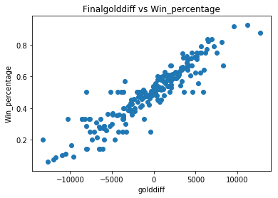

|  | blueTeamTag | bResult | rResult | finalgolddiff | win_percent |
| --- | --- | --- | --- | --- | --- |
| 1 | 17A | 1 | 3 | -429.500000 | 0.250000 |
| 2 | 7h | 18 | 17 | -1290.857143 | 0.514286 |
| 3 | A | 6 | 11 | -4379.647059 | 0.352941 |
| 4 | AE | 15 | 23 | -2884.078947 | 0.394737 |
| 5 | AF | 3 | 1 | 4543.750000 | 0.750000 |
| 6 | AFR | 1 | 1 | -8093.500000 | 0.500000 |
| 7 | AFs | 65 | 46 | 2697.144144 | 0.585586 |
| 8 | AHQ | 16 | 15 | 867.903226 | 0.516129 |
| 10 | ANC | 12 | 14 | -500.576923 | 0.461538 |
| 11 | ANX | 15 | 4 | 5670.368421 | 0.789474 |
| 12 | APX | 14 | 14 | 234.892857 | 0.500000 |
| 13 | AS | 4 | 9 | -6905.846154 | 0.307692 |
| 15 | AUR | 42 | 25 | 2599.223881 | 0.626866 |
| 16 | AV | 30 | 29 | -53.983051 | 0.508475 |
| 17 | B2K | 3 | 9 | -3741.916667 | 0.250000 |
| 18 | BC | 1 | 8 | -10560.888889 | 0.111111 |
| 19 | BE | 1 | 9 | -10995.400000 | 0.100000 |
| 20 | BGG | 1 | 6 | -7959.714286 | 0.142857 |
| 21 | BJK | 33 | 21 | 1987.537037 | 0.611111 |
| 24 | BPI | 2 | 5 | -5931.285714 | 0.285714 |
| 25 | C9 | 90 | 63 | 2320.052288 | 0.588235 |
| 27 | CA | 4 | 3 | 1460.857143 | 0.571429 |
| 29 | CG | 2 | 1 | 1988.000000 | 0.666667 |
| 30 | CGE | 1 | 15 | -12662.375000 | 0.062500 |
| 31 | CHF | 46 | 21 | 3945.074627 | 0.686567 |
| 32 | CJ | 14 | 9 | 1680.478261 | 0.608696 |
| 33 | CJE | 39 | 41 | -111.375000 | 0.487500 |
| 35 | CLG | 92 | 62 | 1012.487013 | 0.597403 |
| 36 | CLK | 10 | 25 | -5957.942857 | 0.285714 |
| 37 | CNB | 13 | 21 | -2240.352941 | 0.382353 |
| ... | ... | ... | ... | ... | ... |
| 204 | TL | 76 | 57 | 1175.037594 | 0.571429 |
| 206 | TM | 14 | 40 | -5674.500000 | 0.259259 |
| 207 | TPA | 24 | 18 | 3366.738095 | 0.571429 |
| 208 | TRC | 1 | 1 | -1663.000000 | 0.500000 |
| 209 | TRI | 6 | 6 | -1666.500000 | 0.500000 |
| 211 | TSM | 104 | 42 | 4447.438356 | 0.712329 |
| 213 | TT | 25 | 20 | 216.311111 | 0.555556 |
| 215 | TY | 1 | 4 | -4689.800000 | 0.200000 |
| 216 | UOL | 65 | 57 | 227.565574 | 0.532787 |
| 217 | USG | 23 | 15 | 4352.289474 | 0.605263 |
| 218 | VEG | 22 | 16 | 422.684211 | 0.578947 |
| 219 | VFK | 15 | 5 | 5532.800000 | 0.750000 |
| 220 | VIT | 29 | 28 | -346.736842 | 0.508772 |
| 221 | VK | 1 | 1 | 4675.500000 | 0.500000 |
| 222 | VP | 13 | 11 | 3193.875000 | 0.541667 |
| 223 | VS | 16 | 18 | -1838.382353 | 0.470588 |
| 224 | WE | 16 | 8 | 4019.625000 | 0.666667 |
| 225 | WFX | 6 | 5 | 2053.090909 | 0.545455 |
| 227 | WS | 10 | 16 | -2745.653846 | 0.384615 |
| 228 | Winners | 1 | 1 | -4296.000000 | 0.500000 |
| 229 | X5 | 1 | 10 | -11745.272727 | 0.090909 |
| 230 | XG | 14 | 33 | -4998.021277 | 0.297872 |
| 232 | YC | 1 | 3 | -7121.750000 | 0.250000 |
| 234 | ZONE | 2 | 5 | -8058.000000 | 0.285714 |
| 235 | ZTG | 12 | 17 | -3061.827586 | 0.413793 |
| 236 | ahq | 76 | 20 | 7178.156250 | 0.791667 |
| 238 | bbq | 26 | 24 | 816.820000 | 0.520000 |
| 239 | g3x | 1 | 6 | -6427.428571 | 0.142857 |
| 240 | kt | 101 | 62 | 3030.263804 | 0.619632 |
| 241 | yoeFW | 6 | 2 | 5668.625000 | 0.750000 |

205 rows × 5 columns

```python
x=list()
for a, b in zip(LoL['golddiff'], LoL['gamelength']):
    a = a[1:len(a)-1]
    c =a.split(',')
    c = list(map(int, c))
    x.append(c[b-1])
LoL['finalgolddiff']=x
LoL_teams = LoL.groupby(['blueTeamTag'], as_index=False)['bResult', 'rResult','finalgolddiff'].sum()
LoL_teams['finalgolddiff']=pd.to_numeric(LoL_teams['finalgolddiff']) / (pd.to_numeric(LoL_teams['bResult']) + pd.to_numeric(LoL_teams['rResult']))
LoL_teams['win_percent'] = pd.to_numeric(LoL_teams['bResult']) / (pd.to_numeric(LoL_teams['bResult']) + pd.to_numeric(LoL_teams['rResult']))
LoL_teams=LoL_teams[LoL_teams.win_percent != 1]
LoL_teams=LoL_teams[LoL_teams.win_percent != 0]
plt.title('Finalgolddiff vs Win_percentage')
plt.xlabel('golddiff')
plt.ylabel('Win_percentage')
plt.scatter(x=LoL_teams.finalgolddiff, y=LoL_teams.win_percent)
plt.show()
LoL_teams
```

One helpful feature python offers is dictionaries which will give you the ability to covert values within and between dataframes so that they can be cross analyzed. Can you see why I performed the next step?

```python
diction = dict(zip(LoL.Address,LoL.blueTeamTag))
structures['Team']=structures['Address'].map(diction)
matchinfo['Team']=matchinfo['Address'].map(diction)
bans['Team']=bans['Address'].map(diction)
kills['Team']=kills['Address'].map(diction)
diction
```

[output not shown]

Correct, so that all the dataframes will have the option of intuitively grouping by team. In our first visualization we saw a positive trend between winning an having more gold than your opponent. Now we want to see if the two main ways of making gold will have the same trend

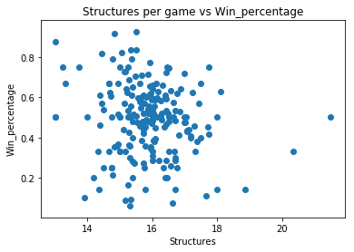

|  | blueTeamTag | bResult | rResult | structures | win_percent |
| --- | --- | --- | --- | --- | --- |
| 1 | 17A | 1 | 3 | 15.750000 | 0.250000 |
| 2 | 7h | 18 | 17 | 15.428571 | 0.514286 |
| 3 | A | 6 | 11 | 15.941176 | 0.352941 |
| 4 | AE | 15 | 23 | 16.078947 | 0.394737 |
| 5 | AF | 3 | 1 | 13.250000 | 0.750000 |
| 6 | AFR | 1 | 1 | 16.000000 | 0.500000 |
| 7 | AFs | 65 | 46 | 15.981982 | 0.585586 |
| 8 | AHQ | 16 | 15 | 14.935484 | 0.516129 |
| 10 | ANC | 12 | 14 | 14.384615 | 0.461538 |
| 11 | ANX | 15 | 4 | 15.368421 | 0.789474 |
| 12 | APX | 14 | 14 | 16.642857 | 0.500000 |
| 13 | AS | 4 | 9 | 16.000000 | 0.307692 |
| 15 | AUR | 42 | 25 | 16.164179 | 0.626866 |
| 16 | AV | 30 | 29 | 15.322034 | 0.508475 |
| 17 | B2K | 3 | 9 | 16.333333 | 0.250000 |
| 18 | BC | 1 | 8 | 17.666667 | 0.111111 |
| 19 | BE | 1 | 9 | 13.900000 | 0.100000 |
| 20 | BGG | 1 | 6 | 18.857143 | 0.142857 |
| 21 | BJK | 33 | 21 | 15.740741 | 0.611111 |
| 24 | BPI | 2 | 5 | 16.428571 | 0.285714 |
| 25 | C9 | 90 | 63 | 16.091503 | 0.588235 |
| 27 | CA | 4 | 3 | 14.428571 | 0.571429 |
| 29 | CG | 2 | 1 | 14.666667 | 0.666667 |
| 30 | CGE | 1 | 15 | 15.312500 | 0.062500 |
| 31 | CHF | 46 | 21 | 15.268657 | 0.686567 |
| 32 | CJ | 14 | 9 | 16.391304 | 0.608696 |
| 33 | CJE | 39 | 41 | 16.287500 | 0.487500 |
| 35 | CLG | 92 | 62 | 16.142857 | 0.597403 |
| 36 | CLK | 10 | 25 | 16.200000 | 0.285714 |
| 37 | CNB | 13 | 21 | 17.382353 | 0.382353 |
| ... | ... | ... | ... | ... | ... |
| 204 | TL | 76 | 57 | 15.759398 | 0.571429 |
| 206 | TM | 14 | 40 | 16.574074 | 0.259259 |
| 207 | TPA | 24 | 18 | 15.666667 | 0.571429 |
| 208 | TRC | 1 | 1 | 21.500000 | 0.500000 |
| 209 | TRI | 6 | 6 | 15.333333 | 0.500000 |
| 211 | TSM | 104 | 42 | 15.863014 | 0.712329 |
| 213 | TT | 25 | 20 | 16.066667 | 0.555556 |
| 215 | TY | 1 | 4 | 16.400000 | 0.200000 |
| 216 | UOL | 65 | 57 | 16.426230 | 0.532787 |
| 217 | USG | 23 | 15 | 14.710526 | 0.605263 |
| 218 | VEG | 22 | 16 | 15.631579 | 0.578947 |
| 219 | VFK | 15 | 5 | 16.450000 | 0.750000 |
| 220 | VIT | 29 | 28 | 15.508772 | 0.508772 |
| 221 | VK | 1 | 1 | 17.000000 | 0.500000 |
| 222 | VP | 13 | 11 | 16.000000 | 0.541667 |
| 223 | VS | 16 | 18 | 15.705882 | 0.470588 |
| 224 | WE | 16 | 8 | 14.958333 | 0.666667 |
| 225 | WFX | 6 | 5 | 15.636364 | 0.545455 |
| 227 | WS | 10 | 16 | 16.038462 | 0.384615 |
| 228 | Winners | 1 | 1 | 13.000000 | 0.500000 |
| 229 | X5 | 1 | 10 | 15.181818 | 0.090909 |
| 230 | XG | 14 | 33 | 15.319149 | 0.297872 |
| 232 | YC | 1 | 3 | 14.750000 | 0.250000 |
| 234 | ZONE | 2 | 5 | 16.000000 | 0.285714 |
| 235 | ZTG | 12 | 17 | 16.827586 | 0.413793 |
| 236 | ahq | 76 | 20 | 14.770833 | 0.791667 |
| 238 | bbq | 26 | 24 | 16.300000 | 0.520000 |
| 239 | g3x | 1 | 6 | 16.714286 | 0.142857 |
| 240 | kt | 101 | 62 | 15.938650 | 0.619632 |
| 241 | yoeFW | 6 | 2 | 15.250000 | 0.750000 |

205 rows × 5 columns

```python
structures['count']=1
structures_teams=structures.groupby(['Team'], as_index=False)['count'].sum()
LoL_teams = LoL.groupby(['blueTeamTag'], as_index=False)['bResult', 'rResult'].sum()
LoL_teams['structures']=pd.to_numeric(structures_teams['count']) / (pd.to_numeric(LoL_teams['bResult']) + pd.to_numeric(LoL_teams['rResult']))
LoL_teams['win_percent'] = pd.to_numeric(LoL_teams['bResult']) / (pd.to_numeric(LoL_teams['bResult']) + pd.to_numeric(LoL_teams['rResult']))
LoL_teams=LoL_teams[LoL_teams.win_percent != 1]
LoL_teams=LoL_teams[LoL_teams.win_percent != 0]
plt.title('Structures per game vs Win_percentage')
plt.xlabel('Structures')
plt.ylabel('Win_percentage')
plt.scatter(x=LoL_teams.structures, y=LoL_teams.win_percent)
plt.show()
LoL_teams
```

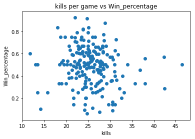

|  | blueTeamTag | bResult | rResult | kills | win_percent |
| --- | --- | --- | --- | --- | --- |
| 1 | 17A | 1 | 3 | 26.000000 | 0.250000 |
| 2 | 7h | 18 | 17 | 22.742857 | 0.514286 |
| 3 | A | 6 | 11 | 30.294118 | 0.352941 |
| 4 | AE | 15 | 23 | 28.552632 | 0.394737 |
| 5 | AF | 3 | 1 | 18.750000 | 0.750000 |
| 6 | AFR | 1 | 1 | 19.500000 | 0.500000 |
| 7 | AFs | 65 | 46 | 21.594595 | 0.585586 |
| 8 | AHQ | 16 | 15 | 24.903226 | 0.516129 |
| 10 | ANC | 12 | 14 | 28.538462 | 0.461538 |
| 11 | ANX | 15 | 4 | 22.526316 | 0.789474 |
| 12 | APX | 14 | 14 | 24.607143 | 0.500000 |
| 13 | AS | 4 | 9 | 26.692308 | 0.307692 |
| 15 | AUR | 42 | 25 | 31.104478 | 0.626866 |
| 16 | AV | 30 | 29 | 28.355932 | 0.508475 |
| 17 | B2K | 3 | 9 | 26.666667 | 0.250000 |
| 18 | BC | 1 | 8 | 26.000000 | 0.111111 |
| 19 | BE | 1 | 9 | 14.200000 | 0.100000 |
| 20 | BGG | 1 | 6 | 30.571429 | 0.142857 |
| 21 | BJK | 33 | 21 | 28.462963 | 0.611111 |
| 24 | BPI | 2 | 5 | 32.142857 | 0.285714 |
| 25 | C9 | 90 | 63 | 24.986928 | 0.588235 |
| 27 | CA | 4 | 3 | 30.428571 | 0.571429 |
| 29 | CG | 2 | 1 | 22.666667 | 0.666667 |
| 30 | CGE | 1 | 15 | 24.812500 | 0.062500 |
| 31 | CHF | 46 | 21 | 26.104478 | 0.686567 |
| 32 | CJ | 14 | 9 | 22.391304 | 0.608696 |
| 33 | CJE | 39 | 41 | 24.037500 | 0.487500 |
| 35 | CLG | 92 | 62 | 27.422078 | 0.597403 |
| 36 | CLK | 10 | 25 | 28.285714 | 0.285714 |
| 37 | CNB | 13 | 21 | 22.205882 | 0.382353 |
| ... | ... | ... | ... | ... | ... |
| 204 | TL | 76 | 57 | 25.616541 | 0.571429 |
| 206 | TM | 14 | 40 | 27.203704 | 0.259259 |
| 207 | TPA | 24 | 18 | 25.714286 | 0.571429 |
| 208 | TRC | 1 | 1 | 26.500000 | 0.500000 |
| 209 | TRI | 6 | 6 | 24.666667 | 0.500000 |
| 211 | TSM | 104 | 42 | 25.109589 | 0.712329 |
| 213 | TT | 25 | 20 | 26.088889 | 0.555556 |
| 215 | TY | 1 | 4 | 24.600000 | 0.200000 |
| 216 | UOL | 65 | 57 | 27.885246 | 0.532787 |
| 217 | USG | 23 | 15 | 22.868421 | 0.605263 |
| 218 | VEG | 22 | 16 | 24.105263 | 0.578947 |
| 219 | VFK | 15 | 5 | 19.700000 | 0.750000 |
| 220 | VIT | 29 | 28 | 22.508772 | 0.508772 |
| 221 | VK | 1 | 1 | 13.500000 | 0.500000 |
| 222 | VP | 13 | 11 | 25.875000 | 0.541667 |
| 223 | VS | 16 | 18 | 28.411765 | 0.470588 |
| 224 | WE | 16 | 8 | 23.916667 | 0.666667 |
| 225 | WFX | 6 | 5 | 30.727273 | 0.545455 |
| 227 | WS | 10 | 16 | 21.230769 | 0.384615 |
| 228 | Winners | 1 | 1 | 34.000000 | 0.500000 |
| 229 | X5 | 1 | 10 | 30.636364 | 0.090909 |
| 230 | XG | 14 | 33 | 24.234043 | 0.297872 |
| 232 | YC | 1 | 3 | 13.500000 | 0.250000 |
| 234 | ZONE | 2 | 5 | 42.428571 | 0.285714 |
| 235 | ZTG | 12 | 17 | 24.206897 | 0.413793 |
| 236 | ahq | 76 | 20 | 24.979167 | 0.791667 |
| 238 | bbq | 26 | 24 | 19.000000 | 0.520000 |
| 239 | g3x | 1 | 6 | 31.142857 | 0.142857 |
| 240 | kt | 101 | 62 | 23.785276 | 0.619632 |
| 241 | yoeFW | 6 | 2 | 26.625000 | 0.750000 |

205 rows × 5 columns

```python
kills['count']=1
kills_teams=kills.groupby(['Team'], as_index=False)['count'].sum()
LoL_teams = LoL.groupby(['blueTeamTag'], as_index=False)['bResult', 'rResult'].sum()
LoL_teams['kills']=pd.to_numeric(kills_teams['count']) / (pd.to_numeric(LoL_teams['bResult']) + pd.to_numeric(LoL_teams['rResult']))
LoL_teams['win_percent'] = pd.to_numeric(LoL_teams['bResult']) / (pd.to_numeric(LoL_teams['bResult']) + pd.to_numeric(LoL_teams['rResult']))
LoL_teams=LoL_teams[LoL_teams.win_percent != 1]
LoL_teams=LoL_teams[LoL_teams.win_percent != 0]
plt.title('kills per game vs Win_percentage')
plt.xlabel('kills')
plt.ylabel('Win_percentage')
plt.scatter(x=LoL_teams.kills, y=LoL_teams.win_percent)
plt.show()
LoL_teams
```

Hmmm just by looking at the graphs we can see that the trends in the second and thrid visualization are not the same as the first visualization. This is what some of you expected though already. Data tells stories and some stories are more full and rich than others. Essentially, the second and third stories were the first one with pages ripped out. The information present (or richness) is shown by how much x explains y in a scatter plot linear regression shown below. The best indication of the fullness of an explanation is the r_value shown below

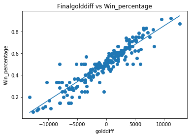

```
(3.4212639957723435e-05,
 0.51054155563061276,
 0.9180958502584784,
 1.5713058356895277e-83,
 1.036665509798702e-06)
```

```python
LoL['finalgolddiff']=x
LoL_teams = LoL.groupby(['blueTeamTag'], as_index=False)['bResult', 'rResult','finalgolddiff'].sum()
LoL_teams['finalgolddiff']=pd.to_numeric(LoL_teams['finalgolddiff']) / (pd.to_numeric(LoL_teams['bResult']) + pd.to_numeric(LoL_teams['rResult']))
LoL_teams['win_percent'] = pd.to_numeric(LoL_teams['bResult']) / (pd.to_numeric(LoL_teams['bResult']) + pd.to_numeric(LoL_teams['rResult']))
LoL_teams=LoL_teams[LoL_teams.win_percent != 1]
LoL_teams=LoL_teams[LoL_teams.win_percent != 0]
plt.title('Finalgolddiff vs Win_percentage')
plt.xlabel('golddiff')
plt.ylabel('Win_percentage')
plt.scatter(x=LoL_teams.finalgolddiff, y=LoL_teams.win_percent)
slope, intercept, r_value, p_value, std_err = stats.linregress(LoL_teams.finalgolddiff,LoL_teams.win_percent)
min_x = float(min(LoL_teams.finalgolddiff))
min_y = float(min_x)*float(slope) + float(intercept)
max_x = float(max(LoL_teams.finalgolddiff))
max_y = float(max_x)*float(slope) + float(intercept)
plt.plot([min_x, max_x], [min_y, max_y])
plt.show()
slope, intercept, r_value, p_value, std_err
```

Python has many more tools to offer shown below, I encourge you not only to start coding, but also build a strong background in statistics for the future

```python
#import seaborn as sns
#from sklearn import model_selection
#from sklearn import linear_model
#import statsmodels.formula.api as smf
```